# 고객 데이터 분석

### 데이터 출처 : UCI Machine Learning Repository

[링크주소 및 다운로드]https://archive.ics.uci.edu/ml/datasets/bank+marketing

#### Moro, S., Cortez, P., & Rita, P. (2014). A data-driven approach to predict the success of bank telemarketing. Decision Support Systems, 62, 22-31

# <데이터 소개>

- 해외의 은행이 진행한 마케팅 데이터
- 아웃바운드 텔레마케팅으로 마케팅 캠페인을 진행

# bank client data:

1 - age (numeric)  
2 - job : type of job (categorical: 'admin.','blue-collar','entrepreneur','housemaid','management','retired','self-employed','services','student','technician','unemployed','unknown')  
3 - marital : marital status (categorical: 'divorced','married','single','unknown'; note: 'divorced' means divorced or widowed)  
4 - education (categorical: 'basic.4y','basic.6y','basic.9y','high.school','illiterate','professional.course','university.degree','unknown')  
5 - default: has credit in default? (categorical: 'no','yes','unknown')  
6 - housing: has housing loan? (categorical: 'no','yes','unknown')  
7 - loan: has personal loan? (categorical: 'no','yes','unknown')

# related with the last contact of the current campaign:

8 - contact: contact communication type (categorical: 'cellular','telephone')  
9 - month: last contact month of year (categorical: 'jan', 'feb', 'mar', ..., 'nov', 'dec')  
10 - day_of_week: last contact day of the week (categorical: 'mon','tue','wed','thu','fri')  
11 - duration: last contact duration, in seconds (numeric).

# other attributes:

12 - campaign: number of contacts performed during this campaign and for this client (numeric, includes last contact)  
13 - pdays: number of days that passed by after the client was last contacted from a previous campaign (numeric; 999 means client was not previously contacted)  
14 - previous: number of contacts performed before this campaign and for this client (numeric)  
15 - poutcome: outcome of the previous marketing campaign (categorical: 'failure','nonexistent','success')

# social and economic context attributes

16 - emp.var.rate: employment variation rate - quarterly indicator (numeric)  
17 - cons.price.idx: consumer price index - monthly indicator (numeric)  
18 - cons.conf.idx: consumer confidence index - monthly indicator (numeric)  
19 - euribor3m: euribor 3 month rate - daily indicator (numeric)  
20 - nr.employed: number of employees - quarterly indicator (numeric)

# Output variable:

21 - y - has the client subscribed a term deposit? (binary: 'yes','no')

```python
import pandas as pd
from pandas import Series
from pandas import DataFrame
```

```python
import matplotlib.pyplot as plt
```

```python
# matplotlib 한글 폰트 출력코드
# 출처 : 데이터공방( https://kiddwannabe.blog.me)

import matplotlib
from matplotlib import font_manager, rc
import platform

try :
    if platform.system() == 'Windows':
    # 윈도우인 경우
        font_name = font_manager.FontProperties(fname="c:/Windows/Fonts/malgun.ttf").get_name()
        rc('font', family=font_name)
    else:
    # Mac 인 경우
        rc('font', family='AppleGothic')
except :
    pass
matplotlib.rcParams['axes.unicode_minus'] = False
```

# 데이터불러오기

파일명 : bank-additional-full.csv

```python
#window 방법1 : \\
#engine='python' - 에러 반환시, 디렉토리 혹은 파일명에 한글이 있을 경우 추가
df=pd.read_csv('C:\\Users\\bank-additional-full.csv',
                 engine='python')
```

```python
#window 방법2 : /
df=pd.read_csv('C:/Users/bank-additional-full.csv',
                 engine='python')
```

```python
#window 방법# : r
df=pd.read_csv(r'C:/Users/bank-additional-full.csv',
                 engine='python')
```

```python
#mac
df=pd.read_csv('/users/junghs/bank-additional-full.csv')
```

```python
#head()
```

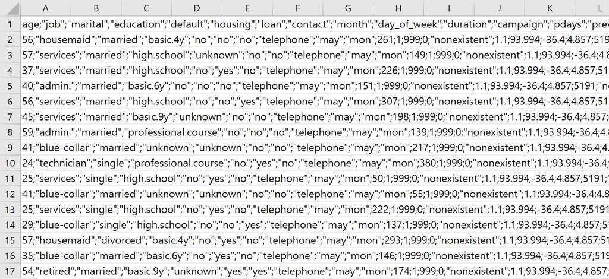

```python
#window
#sep = ';'
df=pd.read_csv('C:/Users/bank-additional-full.csv',
                 engine='python',sep=';')
```

```python
#mac
#sep = ';'
```

## # 데이터탐색

```python
#head - 데이터의 첫 5행, default : 5행
```

```python
#tail - 데이터의 끝 5행, default : 5행
```

# 결측치 확인

```python
# 결측치 확인
```

```python
# 결측치 확인 - 열단위
```

```python
#shape - dataframe의 크기(행, 열의 수)
```

```python
#describe() - 열에 대한 기술통계량
#데이터의 수, 평균, 표준편차, 최소값, 1사분위수, 2사분위수, 3사분위수, 최대값
```

```python
#columns - 칼럼명 반환
```

```python
#unique() - 열의 고유값
#education
```

```python
#value_counts() - 열의 고유값 빈도
#education
```

```python
#unique() - 열의 고유값
#marital
```

```python
#value_counts() - 열의 고유값 빈도
#marital
```

# 데이터 시각화

```python
df['age']
```

[output not shown]

```python
df['age'].plot()
plt.show()
#x축이 인덱스 순서
```

[output not shown]

- age 칼럼 선그래프 그리기(오름차순)
  1. 노출수칼럼을 수치 순서대로 오름차순 정렬
  2. 정렬된 데이터(시리즈)의 형태대로 인덱스 재생성

```python
#오름차순 정렬
#age칼럼
age=df['age'].sort_values()
```

```python
#age변수출력
```

```python
#reset_index - 인덱스 재생성, 기존 인덱스를 데이터프레임의 열로 반환
```

```python
#age 변수출력
```

```python
#drop(axis=1) - 삭제(열 기준)
```

```python
#age 변수출력
```

```python
#plotting
#값의 오름차순별로 정렬한 그래프
#보통 '나이'를 20대,30대,40..대로 나누어 데이터를 확인함
```

```python
#계급간 빈도를 나타내주는 히스토그램
```

```python
#히스토그램
#bins - 계급구간(10,20,30...100)
#figsize=[15,8]
#xticks(fontsize=15)
#yticks(fontsize=15)
#plt.title('Histogram of df.age',fontsize=20)

df['age'].plot.hist(bins=range(10,101,10),figsize=[15,8])
plt.xticks(fontsize=15)
plt.yticks(fontsize=15)
plt.title('Histogram of df.age',fontsize=20)
plt.show()
```

[output not shown]

```python
#시각화 예제2 : duration(전화통화시간) 선 그래프 시각화
(((df['duration'].sort_values()).reset_index()).drop('index',axis=1)).plot()
plt.show()
#1. 선그래프로 데이터의 패턴 분석
#2. 히스토그램으로 전화통화 시간별 빈도 분석
```

[output not shown]

```python
#히스토그램의 계급구간을 설정하기 위한 최소값, 최대값 파악
#describe()
```

```python
#bins=range(0,5000,100)
```

```python
#히스토그램
#bins - 계급구간(0,100,200...5000)
#figsize=[15,8]
#xticks(fontsize=15)
#yticks(fontsize=15)
#plt.title('Histogram of df.duration',fontsize=20)

df['duration'].plot.hist(bins=range(0,5001,100), figsize=[15,8])
plt.xticks(fontsize=15)
plt.yticks(fontsize=15)
plt.title('Histogram of df.duration',fontsize=20)
plt.show()
```

[output not shown]

# 막대그래프, 가로막대그래프

```python
#선그래프
#marital
df['marital'].plot()
#no numeric data to plot
```

```python
#히스토그램
df['marital'].plot.hist()
#no numeric data to plot
```

```python
#unique()함수를 사용한 age칼럼 고유값 확인

#선그래프를 그린 age칼럼 데이터는 수치데이터
```

```python
#unique()함수를 사용한 marital칼럼 고유값 확인

#marital칼럼의 데이터는 문자
```

```python
#unique()함수를 사용한 education칼럼 고유값 확인

#education칼럼의 데이터는 문자
```

- 막대그래프를 통한 시각화
  1. value_counts
  2. 막대그래프 시각화

```python
#1. value_counts()
#marital
```

```python
#2. marital변수 막대그래프 시각화
```

```python
#2-1. 가로막대그래프 시각화
```

```python
#education 가로막대그래프 한줄 코드
#value_counts(),plot.barh()
```

# 분석주제 1 :

### 대출이 있는 사람이라면 은행 상품에 잘 가입하지 않을 것이다.

- 학습목표 :
  1. 가설검증과정 코딩 실습하기
  2. groupby활용한 실습 진행하기
- 분석을 위한 코딩과정 도식화
  1. 가입여부에 따라 가입한 그룹과 가입하지 않은 그룹으로 나눈다.
  2. 나뉜 데이터를 대출여부에 따라 나눈다.
  3. 가입한 그룹 중 대출이 있는 사람의 비중과, 가입하지 않은 그룹 중 대출이 있는 사람의 비중을 비교한다.

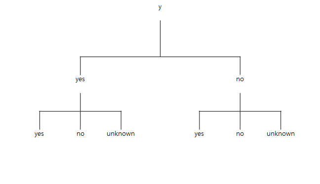

```python
# 1. 가입여부에 따라 가입한 그룹과 가입하지 않은 그룹으로 나눈다.
#가입여부에 대한 칼럼 : 'y'
#unique()

#groupby사용 - yes, no그룹으로 나뉘게 됨
```

```python
# 1. 가입여부에 따라 가입한 그룹과 가입하지 않은 그룹으로 나눈다.
#groupby('y')
```

```python
# 1. 가입여부에 따라 가입한 그룹과 가입하지 않은 그룹으로 나눈다.
#get_group('yes') - y칼럼이 'yes'인 데이터프레임 추출 - 가입한 그룹만 추출
#get_group('no') - y칼럼이 'no'인 데이터프레임 추출 - 가입하지 않은 그룹만 추출
```

```python
# 1. 가입여부에 따라 가입한 그룹과 가입하지 않은 그룹으로 나눈다.
#yes_group 출력
```

```python
# 1-3. 가입여부에 따라 가입한 그룹과 가입하지 않은 그룹으로 나눈다.
#no_group 출력
```

```python
#2. 나뉜 데이터(yes_group,no_group)를 대출여부(loan)에 따라 나눈다.
#value_counts
```

```python
#yes변수 출력

#yes_group의 대출여부 빈도 출력
```

```python
#2. 나뉜 데이터(yes_group,no_group)를 대출여부(loan)에 따라 나눈다.
#value_counts
```

```python
#no변수 출력

#no_group의 대출여부 빈도 출력
```

```python
#3. 가입한 그룹 내 대출이 있는 사람의 비중과, 가입하지 않은 그룹 내 대출이 있는 사람의 비중을 비교한다(yes_group).
#비중 : 시리즈 변수 각각의 value를 시리즈의 총합으로 나눔
#시리즈는 산술연산자(+,-,*,/,%,**,//)와 함께 사용가능
#series/series.sum()
```

```python
#yes 출력
```

```python
#3. 가입한 그룹 내 대출이 있는 사람의 비중과, 가입하지 않은 그룹 내 대출이 있는 사람의 비중을 비교한다(no_group).
```

```python
#no 출력
```

```python
#3. 가입한 그룹 중 대출이 있는 사람의 비중과, 가입하지 않은 그룹 중 대출이 있는 사람의 비중을 비교한다.
#concat : 시리즈 혹은 데이터프레임 결합(default-행방향 결합)

#칼럼명이 모두 loan
```

```python
#series.name : 시리즈의 이름 설정
```

```python
#series.name : 시리즈의 이름 설정
```

```python
#=> 가입한 그룹의 대출 비중이 가입하지 않은 그룹보다 0.005 더 적다.
```

[output not shown]

# 분석주제 2 :

# 같은 상품을 새로운 고객에게 마케팅 하려고한다.

# 연령과 상품가입여부, 직업을 함께 고려할때 마케팅 전략을 변화시켜야 할 그룹은?

- 학습목표 :
  1. 가설검증과정 코딩 실습하기
  2. pivot_table활용한 실습 진행하기
- 분석조건 : 세 개의 칼럼(age, job, y)을 함께 분석해야 함
- pd.pivot_table('데이터프레임 변수',values=집계 대상 칼럼(수치 데이터), index=행 인덱스가 될 칼럼명, columns=열 인덱스가 될 칼럼명, aggfunc=집계함수-sum,mean,min,max,std,var)

# pivot_table 사용예제

```python
#pd.pivot_table('데이터프레임 변수',values=집계 대상 칼럼, index=행 인덱스가 될 칼럼명, columns=열 인덱스가 될 칼럼명, aggfunc=sum)
```

```python
#values,index,columns파라미터를 일일이 쓰지 않고 순서대로 입력하여 실행 가능
```

```python
#멀티 인덱스(multi-index) - 행 인덱스
#['y','marital']
```

```python
#멀티 인덱스(multi-index) - 열 인덱스
#['job','contact']
```

```python
#fill-value - 결측치 대체
#fill_value=0
```

# pivot_table를 사용한 주제2 분석

#### 같은 상품을 새로운 고객에게 마케팅 하려고한다.

#### 연령과 상품가입여부, 직업을 함께 고려할때 마케팅 전략을 변화시켜야 할 그룹은?

```python
#pivot_table
```

```python
#pivot 변수 출력
```

```python
#yes행과 no행의 차 연산(loc인덱서 사용)
```

```python
#diff행 생성(yes행과 no행의 차)
```

```python
#pivot 변수 출력
```

```python
#diff 기준으로 내림차순 정렬
#sort_values() - default : 열 기준 오름차순 정렬
#axis=1,ascending=False : 행 기준 내림차순 정렬
```

```python
#result 출력
```

```python
#result의 diff행 막대그래프 시각화
```

```python
#result의 diff행 막대그래프 시각화
#figsize=[15,10]
#title('주제2 시각화',fontsize=20)
#x축 눈금 - fontsize=16,rotation=45
#y축 눈금 - fontsize=16)
#xlabel - 'job',fontsize=16
#ylabel - 'diff',fontsize=16

result.loc['diff'].plot.bar(figsize=[15,10])
plt.title('주제2 시각화',fontsize=20)
plt.xticks(fontsize=16,rotation=45)
plt.yticks(fontsize=16)
plt.xlabel('job',fontsize=16)
plt.ylabel('diff',fontsize=16)
plt.show()
```

[output not shown]